# Q17. Use observations for Mcdonalds to plot sugar variable against protein with `geom_point()`

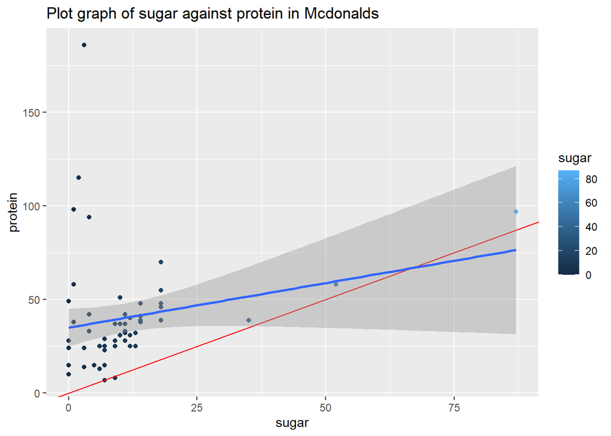

```r
fastfood %>%
  filter(restaurant == "Mcdonalds") %>%
  ggplot(aes(sugar, protein)) +
  geom_point(aes(color = sugar)) +
  geom_abline(color = "red") +
  geom_smooth(method = "lm") +
  labs(size = "Observations",
       x = "sugar",
       y = "protein",
       title = "Plot graph of sugar against protein in Mcdonalds")
```

# Q18. Identify variable(s) which should be factors and transform their type into a factor variable.

```r
str(fastfood)
```

```
## spec_tbl_df [515 x 18] (S3: spec_tbl_df/tbl_df/tbl/data.frame)
##  $ ...1       : num [1:515] 1 2 3 4 5 6 7 8 9 10 ...
##  $ restaurant : chr [1:515] "Mcdonalds" "Mcdonalds" "Mcdonalds" "Mcdonalds" ...
##  $ item       : chr [1:515] "Artisan Grilled Chicken Sandwich" "Single Bacon Smokehouse Burger" "Double Bacon Smokehouse Burger" "Grilled Bacon Smokehouse Chicken Sandwich" ...
##  $ calories   : num [1:515] 380 840 1130 750 920 540 300 510 430 770 ...
##  $ cal_fat    : num [1:515] 60 410 600 280 410 250 100 210 190 400 ...
##  $ total_fat  : num [1:515] 7 45 67 31 45 28 12 24 21 45 ...
##  $ sat_fat    : num [1:515] 2 17 27 10 12 10 5 4 11 21 ...
##  $ trans_fat  : num [1:515] 0 1.5 3 0.5 0.5 1 0.5 0 1 2.5 ...
##  $ cholesterol: num [1:515] 95 130 220 155 120 80 40 65 85 175 ...
##  $ sodium     : num [1:515] 1110 1580 1920 1940 1980 950 680 1040 1040 1290 ...
##  $ total_carb : num [1:515] 44 62 63 62 81 46 33 49 35 42 ...
##  $ fiber      : num [1:515] 3 2 3 2 4 3 2 3 2 3 ...
##  $ sugar      : num [1:515] 11 18 18 18 18 9 7 6 7 10 ...
##  $ protein    : num [1:515] 37 46 70 55 46 25 15 25 25 51 ...
##  $ vit_a      : num [1:515] 4 6 10 6 6 10 10 0 20 20 ...
##  $ vit_c      : num [1:515] 20 20 20 25 20 2 2 4 4 6 ...
##  $ calcium    : num [1:515] 20 20 50 20 20 15 10 2 15 20 ...
##  $ salad      : chr [1:515] "Other" "Other" "Other" "Other" ...
##  - attr(*, "spec")=
##   .. cols(
##   ..   ...1 = col_double(),
##   ..   restaurant = col_character(),
##   ..   item = col_character(),
##   ..   calories = col_double(),
##   ..   cal_fat = col_double(),
##   ..   total_fat = col_double(),
##   ..   sat_fat = col_double(),
##   ..   trans_fat = col_double(),
##   ..   cholesterol = col_double(),
##   ..   sodium = col_double(),
##   ..   total_carb = col_double(),
##   ..   fiber = col_double(),
##   ..   sugar = col_double(),
##   ..   protein = col_double(),
##   ..   vit_a = col_double(),
##   ..   vit_c = col_double(),
##   ..   calcium = col_double(),
##   ..   salad = col_character()
##   .. )
##  - attr(*, "problems")=<externalptr>
```

```r
factor_calories <- as.factor(fastfood$calories)
factor_total_fat <- as.factor(fastfood$total_fat)
factor_trans_fat <- as.factor(fastfood$trans_fat)


str(fastfood)
```

```
## spec_tbl_df [515 x 18] (S3: spec_tbl_df/tbl_df/tbl/data.frame)
##  $ ...1       : num [1:515] 1 2 3 4 5 6 7 8 9 10 ...
##  $ restaurant : chr [1:515] "Mcdonalds" "Mcdonalds" "Mcdonalds" "Mcdonalds" ...
##  $ item       : chr [1:515] "Artisan Grilled Chicken Sandwich" "Single Bacon Smokehouse Burger" "Double Bacon Smokehouse Burger" "Grilled Bacon Smokehouse Chicken Sandwich" ...
##  $ calories   : num [1:515] 380 840 1130 750 920 540 300 510 430 770 ...
##  $ cal_fat    : num [1:515] 60 410 600 280 410 250 100 210 190 400 ...
##  $ total_fat  : num [1:515] 7 45 67 31 45 28 12 24 21 45 ...
##  $ sat_fat    : num [1:515] 2 17 27 10 12 10 5 4 11 21 ...
##  $ trans_fat  : num [1:515] 0 1.5 3 0.5 0.5 1 0.5 0 1 2.5 ...
##  $ cholesterol: num [1:515] 95 130 220 155 120 80 40 65 85 175 ...
##  $ sodium     : num [1:515] 1110 1580 1920 1940 1980 950 680 1040 1040 1290 ...
##  $ total_carb : num [1:515] 44 62 63 62 81 46 33 49 35 42 ...
##  $ fiber      : num [1:515] 3 2 3 2 4 3 2 3 2 3 ...
##  $ sugar      : num [1:515] 11 18 18 18 18 9 7 6 7 10 ...
##  $ protein    : num [1:515] 37 46 70 55 46 25 15 25 25 51 ...
##  $ vit_a      : num [1:515] 4 6 10 6 6 10 10 0 20 20 ...
##  $ vit_c      : num [1:515] 20 20 20 25 20 2 2 4 4 6 ...
##  $ calcium    : num [1:515] 20 20 50 20 20 15 10 2 15 20 ...
##  $ salad      : chr [1:515] "Other" "Other" "Other" "Other" ...
##  - attr(*, "spec")=
##   .. cols(
##   ..   ...1 = col_double(),
##   ..   restaurant = col_character(),
##   ..   item = col_character(),
##   ..   calories = col_double(),
##   ..   cal_fat = col_double(),
##   ..   total_fat = col_double(),
##   ..   sat_fat = col_double(),
##   ..   trans_fat = col_double(),
##   ..   cholesterol = col_double(),
##   ..   sodium = col_double(),
##   ..   total_carb = col_double(),
##   ..   fiber = col_double(),
##   ..   sugar = col_double(),
##   ..   protein = col_double(),
##   ..   vit_a = col_double(),
##   ..   vit_c = col_double(),
##   ..   calcium = col_double(),
##   ..   salad = col_character()
##   .. )
##  - attr(*, "problems")=<externalptr>
```

#Q19. Create two new variables:

#Read about `cut_number()` function using Help and add a new variable to the dataset `calories_type`. Use `calories` variable for `cut_number()` function to split it into 3 categories `n=3`, add labels `labels=c("low", "med", "high")` and make the dataset ordered by arranging it according to calories.

# Do not forget to save the updated dataset

```r
calories_type <- fastfood

calories_type <- cut(fastfood$calories, breaks = c(0, 250, 500,Inf),
                         labels=c("low", "med", "high"),

  right = FALSE)

data.frame(fastfood$calories, calories_type)
```

```
##     fastfood.calories calories_type
## 1                 380           med
## 2                 840          high
## 3                1130          high
## 4                 750          high
## 5                 920          high
## 6                 540          high
## 7                 300           med
## 8                 510          high
## 9                 430           med
## 10                770          high
## 11                380           med
## 12                620          high
## 13                530          high
## 14                700          high
```

[output cut: 501 more lines]

# Q20. Create a dataviz that shows the distribution of `calories_type` in food items for each type of restaurant. Think carefully about the choice of data viz. Use facets, coordinates and theme layers to make your data viz visually appealing and meaningful. Use factors related data viz functions.

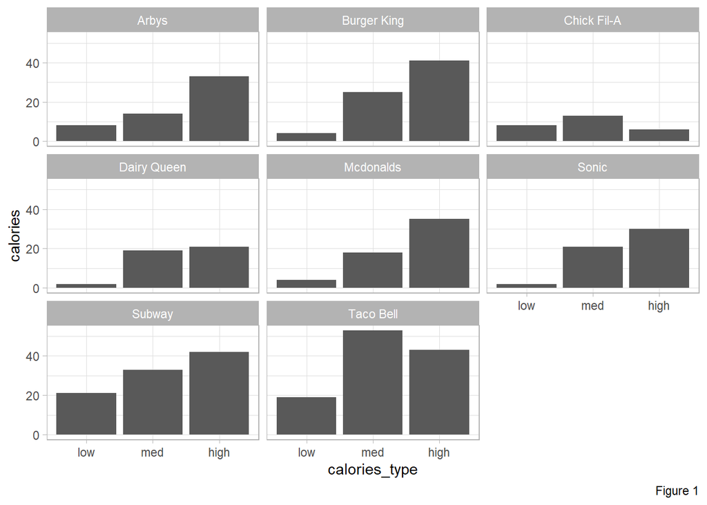

```r
 factor_calories <- calories_type
fastfood %>%
  filter(!str_detect(calories_type, "Total")) %>%

  ggplot(aes(y = calories_type)) +
geom_bar() +
  coord_flip() +
facet_wrap(~fastfood$restaurant) +
  labs(y= "calories_type", x = "calories",colour = "calories_type",
     tiltle = " Distribution of calories_type", caption = "Figure 1") +
  theme_light()
```

#Q21. The second variable should show the percentage of `trans_fat` in `total_fat`. Add the variable to the dataset and call it `trans_fat_percent`. Do not forget to save the updated dataset.

```r
trans_fat_percent <- fastfood %>%

group_by(restaurant) %>%
mutate(percentage = trans_fat / total_fat * 100)
view(trans_fat_percent)
```

#Q22. Create a dataviz that shows the distribution of `trans_fat` in food items for each type of restaurant. Think carefully about the choice of data viz. Use facets, coordinates and theme layers to make your data viz visually appealing and meaningful.

[figure not shown]

```r
fastfood %>%
  select(c(restaurant,trans_fat,item)) %>%
  ggplot(aes(x = item, y = trans_fat)) +
  geom_point(colour = "red") +
facet_wrap(~fastfood$restaurant) +
labs(x= "item", y = "trans_fat",colour = "Transmission",
     tiltle = "Point Chart", caption = "Figure 1") +
  theme_dark()
```

#Q23. Calculate and show the average (mean) `total_fat` for each type of restaurant. No need to save it as a variable.

```r
fastfood %>%
  group_by(restaurant) %>%
  summarise(Average_total_fat = mean(total_fat))
```

```
## # A tibble: 8 x 2
##   restaurant  Average_total_fat
##   <chr>                   <dbl>
## 1 Arbys                    27.0
## 2 Burger King              36.8
## 3 Chick Fil-A              16.1
## 4 Dairy Queen              28.9
## 5 Mcdonalds                31.8
## 6 Sonic                    37.6
## 7 Subway                   18.5
## 8 Taco Bell                20.9
```

#Q24. create a dataviz that allow to compare different restaurants on this variable (`total_fat`). You can present it on one dataviz (= no facets)

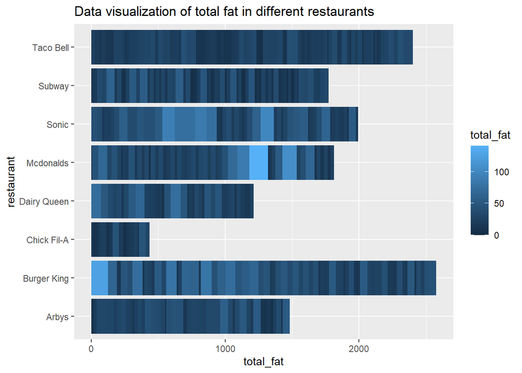

```r
fastfood %>%
ggplot(aes(restaurant, total_fat, fill = total_fat)) +
  geom_col() +
  coord_flip() +
  labs(x = "restaurant", y = "total_fat", fill = "total_fat",
       title = "Data visualization of total fat in different restaurants")
```